# IMDB: Investigate a Dataset

- Introduction
- Data Wrangling
- Exploratory Data Analysis
- Conclusions

## Introduction

> In this analysis we will look at the movie industry and how it changes over the year.

Import our libraries to get started.

```python
%matplotlib inline

import seaborn as sn
import pandas as pd
import numpy as np
import matplotlib.pyplot as plt
```

## Data Wrangling

### General Properties

Here I upload the dataset and take a look at the columns of the dataset and the first five rows.

```python
df = pd.read_csv('tmdb.csv')
df.head()
```

|  | id | imdb_id | popularity | budget | revenue | original_title | cast | homepage | director | tagline | ... | overview | runtime | genres | production_companies | release_date | vote_count | vote_average | release_year | budget_adj | revenue_adj |
| --- | --- | --- | --- | --- | --- | --- | --- | --- | --- | --- | --- | --- | --- | --- | --- | --- | --- | --- | --- | --- | --- |
| 0 | 135397 | tt0369610 | 32.985763 | 150000000 | 1513528810 | Jurassic World | Chris Pratt\|Bryce Dallas Howard\|Irrfan Khan\|Vi... | http://www.jurassicworld.com/ | Colin Trevorrow | The park is open. | ... | Twenty-two years after the events of Jurassic ... | 124 | Action\|Adventure\|Science Fiction\|Thriller | Universal Studios\|Amblin Entertainment\|Legenda... | 6/9/15 | 5562 | 6.5 | 2015 | 1.379999e+08 | 1.392446e+09 |
| 1 | 76341 | tt1392190 | 28.419936 | 150000000 | 378436354 | Mad Max: Fury Road | Tom Hardy\|Charlize Theron\|Hugh Keays-Byrne\|Nic... | http://www.madmaxmovie.com/ | George Miller | What a Lovely Day. | ... | An apocalyptic story set in the furthest reach... | 120 | Action\|Adventure\|Science Fiction\|Thriller | Village Roadshow Pictures\|Kennedy Miller Produ... | 5/13/15 | 6185 | 7.1 | 2015 | 1.379999e+08 | 3.481613e+08 |
| 2 | 262500 | tt2908446 | 13.112507 | 110000000 | 295238201 | Insurgent | Shailene Woodley\|Theo James\|Kate Winslet\|Ansel... | http://www.thedivergentseries.movie/#insurgent | Robert Schwentke | One Choice Can Destroy You | ... | Beatrice Prior must confront her inner demons ... | 119 | Adventure\|Science Fiction\|Thriller | Summit Entertainment\|Mandeville Films\|Red Wago... | 3/18/15 | 2480 | 6.3 | 2015 | 1.012000e+08 | 2.716190e+08 |
| 3 | 140607 | tt2488496 | 11.173104 | 200000000 | 2068178225 | Star Wars: The Force Awakens | Harrison Ford\|Mark Hamill\|Carrie Fisher\|Adam D... | http://www.starwars.com/films/star-wars-episod... | J.J. Abrams | Every generation has a story. | ... | Thirty years after defeating the Galactic Empi... | 136 | Action\|Adventure\|Science Fiction\|Fantasy | Lucasfilm\|Truenorth Productions\|Bad Robot | 12/15/15 | 5292 | 7.5 | 2015 | 1.839999e+08 | 1.902723e+09 |
| 4 | 168259 | tt2820852 | 9.335014 | 190000000 | 1506249360 | Furious 7 | Vin Diesel\|Paul Walker\|Jason Statham\|Michelle ... | http://www.furious7.com/ | James Wan | Vengeance Hits Home | ... | Deckard Shaw seeks revenge against Dominic Tor... | 137 | Action\|Crime\|Thriller | Universal Pictures\|Original Film\|Media Rights ... | 4/1/15 | 2947 | 7.3 | 2015 | 1.747999e+08 | 1.385749e+09 |

5 rows × 21 columns

df.Info take a loo at the diffrenet data types of the dataset

```python
df.info()
```

```
<class 'pandas.core.frame.DataFrame'>
RangeIndex: 10866 entries, 0 to 10865
Data columns (total 21 columns):
id                      10866 non-null int64
imdb_id                 10856 non-null object
popularity              10866 non-null float64
budget                  10866 non-null int64
revenue                 10866 non-null int64
original_title          10866 non-null object
cast                    10790 non-null object
homepage                2936 non-null object
director                10822 non-null object
tagline                 8042 non-null object
keywords                9373 non-null object
overview                10862 non-null object
runtime                 10866 non-null int64
genres                  10843 non-null object
production_companies    9836 non-null object
release_date            10866 non-null object
vote_count              10866 non-null int64
vote_average            10866 non-null float64
release_year            10866 non-null int64
budget_adj              10866 non-null float64
revenue_adj             10866 non-null float64
dtypes: float64(4), int64(6), object(11)
memory usage: 1.7+ MB
```

The dimensions of dataset.

```python
df.shape
```

```
(10866, 21)
```

```python
df.head()
```

|  | id | imdb_id | popularity | budget | revenue | original_title | cast | homepage | director | tagline | ... | overview | runtime | genres | production_companies | release_date | vote_count | vote_average | release_year | budget_adj | revenue_adj |
| --- | --- | --- | --- | --- | --- | --- | --- | --- | --- | --- | --- | --- | --- | --- | --- | --- | --- | --- | --- | --- | --- |
| 0 | 135397 | tt0369610 | 32.985763 | 150000000 | 1513528810 | Jurassic World | Chris Pratt\|Bryce Dallas Howard\|Irrfan Khan\|Vi... | http://www.jurassicworld.com/ | Colin Trevorrow | The park is open. | ... | Twenty-two years after the events of Jurassic ... | 124 | Action\|Adventure\|Science Fiction\|Thriller | Universal Studios\|Amblin Entertainment\|Legenda... | 6/9/15 | 5562 | 6.5 | 2015 | 1.379999e+08 | 1.392446e+09 |
| 1 | 76341 | tt1392190 | 28.419936 | 150000000 | 378436354 | Mad Max: Fury Road | Tom Hardy\|Charlize Theron\|Hugh Keays-Byrne\|Nic... | http://www.madmaxmovie.com/ | George Miller | What a Lovely Day. | ... | An apocalyptic story set in the furthest reach... | 120 | Action\|Adventure\|Science Fiction\|Thriller | Village Roadshow Pictures\|Kennedy Miller Produ... | 5/13/15 | 6185 | 7.1 | 2015 | 1.379999e+08 | 3.481613e+08 |
| 2 | 262500 | tt2908446 | 13.112507 | 110000000 | 295238201 | Insurgent | Shailene Woodley\|Theo James\|Kate Winslet\|Ansel... | http://www.thedivergentseries.movie/#insurgent | Robert Schwentke | One Choice Can Destroy You | ... | Beatrice Prior must confront her inner demons ... | 119 | Adventure\|Science Fiction\|Thriller | Summit Entertainment\|Mandeville Films\|Red Wago... | 3/18/15 | 2480 | 6.3 | 2015 | 1.012000e+08 | 2.716190e+08 |
| 3 | 140607 | tt2488496 | 11.173104 | 200000000 | 2068178225 | Star Wars: The Force Awakens | Harrison Ford\|Mark Hamill\|Carrie Fisher\|Adam D... | http://www.starwars.com/films/star-wars-episod... | J.J. Abrams | Every generation has a story. | ... | Thirty years after defeating the Galactic Empi... | 136 | Action\|Adventure\|Science Fiction\|Fantasy | Lucasfilm\|Truenorth Productions\|Bad Robot | 12/15/15 | 5292 | 7.5 | 2015 | 1.839999e+08 | 1.902723e+09 |
| 4 | 168259 | tt2820852 | 9.335014 | 190000000 | 1506249360 | Furious 7 | Vin Diesel\|Paul Walker\|Jason Statham\|Michelle ... | http://www.furious7.com/ | James Wan | Vengeance Hits Home | ... | Deckard Shaw seeks revenge against Dominic Tor... | 137 | Action\|Crime\|Thriller | Universal Pictures\|Original Film\|Media Rights ... | 4/1/15 | 2947 | 7.3 | 2015 | 1.747999e+08 | 1.385749e+09 |

5 rows × 21 columns

Return the mean of the values skipping all NA values

```python
df.mean(axis=0, skipna=True)
```

```
id              6.606418e+04
popularity      6.464410e-01
budget          1.462570e+07
revenue         3.982332e+07
runtime         1.020709e+02
vote_count      2.173897e+02
vote_average    5.974922e+00
release_year    2.001323e+03
budget_adj      1.755104e+07
revenue_adj     5.136436e+07
dtype: float64
```

Descriptive statistics summarize dataset distribution,

```python
df.describe()
```

|  | id | popularity | budget | revenue | runtime | vote_count | vote_average | release_year | budget_adj | revenue_adj |
| --- | --- | --- | --- | --- | --- | --- | --- | --- | --- | --- |
| count | 10866.000000 | 10866.000000 | 1.086600e+04 | 1.086600e+04 | 10866.000000 | 10866.000000 | 10866.000000 | 10866.000000 | 1.086600e+04 | 1.086600e+04 |
| mean | 66064.177434 | 0.646441 | 1.462570e+07 | 3.982332e+07 | 102.070863 | 217.389748 | 5.974922 | 2001.322658 | 1.755104e+07 | 5.136436e+07 |
| std | 92130.136561 | 1.000185 | 3.091321e+07 | 1.170035e+08 | 31.381405 | 575.619058 | 0.935142 | 12.812941 | 3.430616e+07 | 1.446325e+08 |
| min | 5.000000 | 0.000065 | 0.000000e+00 | 0.000000e+00 | 0.000000 | 10.000000 | 1.500000 | 1960.000000 | 0.000000e+00 | 0.000000e+00 |
| 25% | 10596.250000 | 0.207583 | 0.000000e+00 | 0.000000e+00 | 90.000000 | 17.000000 | 5.400000 | 1995.000000 | 0.000000e+00 | 0.000000e+00 |
| 50% | 20669.000000 | 0.383856 | 0.000000e+00 | 0.000000e+00 | 99.000000 | 38.000000 | 6.000000 | 2006.000000 | 0.000000e+00 | 0.000000e+00 |
| 75% | 75610.000000 | 0.713817 | 1.500000e+07 | 2.400000e+07 | 111.000000 | 145.750000 | 6.600000 | 2011.000000 | 2.085325e+07 | 3.369710e+07 |
| max | 417859.000000 | 32.985763 | 4.250000e+08 | 2.781506e+09 | 900.000000 | 9767.000000 | 9.200000 | 2015.000000 | 4.250000e+08 | 2.827124e+09 |

The sum of duplicate rows

```python
df.duplicated().sum()
```

```
1
```

```python
df.dropna()
df.drop_duplicates(inplace=True)

df.drop(['imdb_id', 'homepage', 'keywords' , 'cast', 'overview', 'director', 'runtime', 'vote_count' , 'vote_average', 'production_companies', 'tagline'], axis=1 , inplace= True)
```

```python
df.head()
```

|  | id | popularity | budget | revenue | original_title | genres | release_date | release_year | budget_adj | revenue_adj |
| --- | --- | --- | --- | --- | --- | --- | --- | --- | --- | --- |
| 0 | 135397 | 32.985763 | 150000000 | 1513528810 | Jurassic World | Action\|Adventure\|Science Fiction\|Thriller | 6/9/15 | 2015 | 1.379999e+08 | 1.392446e+09 |
| 1 | 76341 | 28.419936 | 150000000 | 378436354 | Mad Max: Fury Road | Action\|Adventure\|Science Fiction\|Thriller | 5/13/15 | 2015 | 1.379999e+08 | 3.481613e+08 |
| 2 | 262500 | 13.112507 | 110000000 | 295238201 | Insurgent | Adventure\|Science Fiction\|Thriller | 3/18/15 | 2015 | 1.012000e+08 | 2.716190e+08 |
| 3 | 140607 | 11.173104 | 200000000 | 2068178225 | Star Wars: The Force Awakens | Action\|Adventure\|Science Fiction\|Fantasy | 12/15/15 | 2015 | 1.839999e+08 | 1.902723e+09 |
| 4 | 168259 | 9.335014 | 190000000 | 1506249360 | Furious 7 | Action\|Crime\|Thriller | 4/1/15 | 2015 | 1.747999e+08 | 1.385749e+09 |

I use this function to avoids IndexError and KeyError.

```python
def safe_access(container, i):
    result = container.split('|')
    try:
        return result[i]
    except IndexError or Ksafe_accesseyError:
        return pd.np.nan
```

Next, I will prepare the genres column for for analysis.

```python
data=df[df['genres'].str.contains('|', na=False)]


data.head()
```

|  | id | popularity | budget | revenue | original_title | genres | release_date | release_year | budget_adj | revenue_adj |
| --- | --- | --- | --- | --- | --- | --- | --- | --- | --- | --- |
| 0 | 135397 | 32.985763 | 150000000 | 1513528810 | Jurassic World | Action\|Adventure\|Science Fiction\|Thriller | 6/9/15 | 2015 | 1.379999e+08 | 1.392446e+09 |
| 1 | 76341 | 28.419936 | 150000000 | 378436354 | Mad Max: Fury Road | Action\|Adventure\|Science Fiction\|Thriller | 5/13/15 | 2015 | 1.379999e+08 | 3.481613e+08 |
| 2 | 262500 | 13.112507 | 110000000 | 295238201 | Insurgent | Adventure\|Science Fiction\|Thriller | 3/18/15 | 2015 | 1.012000e+08 | 2.716190e+08 |
| 3 | 140607 | 11.173104 | 200000000 | 2068178225 | Star Wars: The Force Awakens | Action\|Adventure\|Science Fiction\|Fantasy | 12/15/15 | 2015 | 1.839999e+08 | 1.902723e+09 |
| 4 | 168259 | 9.335014 | 190000000 | 1506249360 | Furious 7 | Action\|Crime\|Thriller | 4/1/15 | 2015 | 1.747999e+08 | 1.385749e+09 |

Make new copies if datesets to reorgnize the geners columns

```python
df1=data.copy()
df2=data.copy()
df3=data.copy()
df4=data.copy()
df5=data.copy()


df1['genres']=df1['genres'].apply(lambda x: safe_access(x,0))
df2['genres']=df2['genres'].apply(lambda x: safe_access(x,1))
df3['genres']=df3['genres'].apply(lambda x: safe_access(x,2))
df4['genres']=df4['genres'].apply(lambda x: safe_access(x,3))
df5['genres']=df5['genres'].apply(lambda x: safe_access(x,4))
```

Dropping all the NA values in the five columns.

```python
df1.dropna(subset=['genres'],inplace=True)
df2.dropna(subset=['genres'],inplace=True)
df3.dropna(subset=['genres'],inplace=True)
df4.dropna(subset=['genres'],inplace=True)
df5.dropna(subset=['genres'],inplace=True)
```

Merging the needed dateset into one for the analysis.

```python
df1=df1.append(df2, ignore_index=True)
df3=df3.append(df4,ignore_index=True)
df3=df3.append(df5,ignore_index=True)
dataset=df1.append(df3,ignore_index=True)
dataset
```

|  | id | popularity | budget | revenue | original_title | genres | release_date | release_year | budget_adj | revenue_adj |
| --- | --- | --- | --- | --- | --- | --- | --- | --- | --- | --- |
| 0 | 135397 | 32.985763 | 150000000 | 1513528810 | Jurassic World | Action | 6/9/15 | 2015 | 1.379999e+08 | 1.392446e+09 |
| 1 | 76341 | 28.419936 | 150000000 | 378436354 | Mad Max: Fury Road | Action | 5/13/15 | 2015 | 1.379999e+08 | 3.481613e+08 |
| 2 | 262500 | 13.112507 | 110000000 | 295238201 | Insurgent | Adventure | 3/18/15 | 2015 | 1.012000e+08 | 2.716190e+08 |
| 3 | 140607 | 11.173104 | 200000000 | 2068178225 | Star Wars: The Force Awakens | Action | 12/15/15 | 2015 | 1.839999e+08 | 1.902723e+09 |
| 4 | 168259 | 9.335014 | 190000000 | 1506249360 | Furious 7 | Action | 4/1/15 | 2015 | 1.747999e+08 | 1.385749e+09 |
| 5 | 281957 | 9.110700 | 135000000 | 532950503 | The Revenant | Western | 12/25/15 | 2015 | 1.241999e+08 | 4.903142e+08 |
| 6 | 87101 | 8.654359 | 155000000 | 440603537 | Terminator Genisys | Science Fiction | 6/23/15 | 2015 | 1.425999e+08 | 4.053551e+08 |
| 7 | 286217 | 7.667400 | 108000000 | 595380321 | The Martian | Drama | 9/30/15 | 2015 | 9.935996e+07 | 5.477497e+08 |
| 8 | 211672 | 7.404165 | 74000000 | 1156730962 | Minions | Family | 6/17/15 | 2015 | 6.807997e+07 | 1.064192e+09 |
| 9 | 150540 | 6.326804 | 175000000 | 853708609 | Inside Out | Comedy | 6/9/15 | 2015 | 1.609999e+08 | 7.854116e+08 |
| 10 | 206647 | 6.200282 | 245000000 | 880674609 | Spectre | Action | 10/26/15 | 2015 | 2.253999e+08 | 8.102203e+08 |
| 11 | 76757 | 6.189369 | 176000003 | 183987723 | Jupiter Ascending | Science Fiction | 2/4/15 | 2015 | 1.619199e+08 | 1.692686e+08 |
| 12 | 264660 | 6.118847 | 15000000 | 36869414 | Ex Machina | Drama | 1/21/15 | 2015 | 1.379999e+07 | 3.391985e+07 |
| 13 | 257344 | 5.984995 | 88000000 | 243637091 | Pixels | Action | 7/16/15 | 2015 | 8.095996e+07 | 2.241460e+08 |
| 14 | 99861 | 5.944927 | 280000000 | 1405035767 | Avengers: Age of Ultron | Action | 4/22/15 | 2015 | 2.575999e+08 | 1.292632e+09 |
| 15 | 273248 | 5.898400 | 44000000 | 155760117 | The Hateful Eight | Crime | 12/25/15 | 2015 | 4.047998e+07 | 1.432992e+08 |
| 16 | 260346 | 5.749758 | 48000000 | 325771424 | Taken 3 | Crime | 1/1/15 | 2015 | 4.415998e+07 | 2.997096e+08 |
| 17 | 102899 | 5.573184 | 130000000 | 518602163 | Ant-Man | Science Fiction | 7/14/15 | 2015 | 1.195999e+08 | 4.771138e+08 |
| 18 | 150689 | 5.556818 | 95000000 | 542351353 | Cinderella | Romance | 3/12/15 | 2015 | 8.739996e+07 | 4.989630e+08 |
| 19 | 131634 | 5.476958 | 160000000 | 650523427 | The Hunger Games: Mockingjay - Part 2 | War | 11/18/15 | 2015 | 1.471999e+08 | 5.984813e+08 |
| 20 | 158852 | 5.462138 | 190000000 | 209035668 | Tomorrowland | Action | 5/19/15 | 2015 | 1.747999e+08 | 1.923127e+08 |
| 21 | 307081 | 5.337064 | 30000000 | 91709827 | Southpaw | Action | 6/15/15 | 2015 | 2.759999e+07 | 8.437300e+07 |
| 22 | 254128 | 4.907832 | 110000000 | 470490832 | San Andreas | Action | 5/27/15 | 2015 | 1.012000e+08 | 4.328514e+08 |
| 23 | 216015 | 4.710402 | 40000000 | 569651467 | Fifty Shades of Grey | Drama | 2/11/15 | 2015 | 3.679998e+07 | 5.240791e+08 |
| 24 | 318846 | 4.648046 | 28000000 | 133346506 | The Big Short | Comedy | 12/11/15 | 2015 | 2.575999e+07 | 1.226787e+08 |
| 25 | 177677 | 4.566713 | 150000000 | 682330139 | Mission: Impossible - Rogue Nation | Action | 7/23/15 | 2015 | 1.379999e+08 | 6.277435e+08 |
| 26 | 214756 | 4.564549 | 68000000 | 215863606 | Ted 2 | Comedy | 6/25/15 | 2015 | 6.255997e+07 | 1.985944e+08 |
| 27 | 207703 | 4.503789 | 81000000 | 403802136 | Kingsman: The Secret Service | Crime | 1/24/15 | 2015 | 7.451997e+07 | 3.714978e+08 |
| 28 | 314365 | 4.062293 | 20000000 | 88346473 | Spotlight | Drama | 11/6/15 | 2015 | 1.839999e+07 | 8.127872e+07 |
| 29 | 294254 | 3.968891 | 61000000 | 311256926 | Maze Runner: The Scorch Trials | Action | 9/9/15 | 2015 | 5.611998e+07 | 2.863562e+08 |
| ... | ... | ... | ... | ... | ... | ... | ... | ... | ... | ... |
| 26925 | 11244 | 0.151355 | 30 | 0 | The Meteor Man | Family | 8/6/93 | 1993 | 4.528410e+01 | 0.000000e+00 |
| 26926 | 22213 | 0.271575 | 0 | 0 | Boiling Point | Thriller | 4/16/93 | 1993 | 0.000000e+00 | 0.000000e+00 |
| 26927 | 42700 | 0.438314 | 0 | 0 | The Night of the Generals | Mystery | 1/29/67 | 1967 | 0.000000e+00 | 0.000000e+00 |
| 26928 | 16081 | 0.241283 | 18000000 | 9000000 | Doctor Dolittle | Music | 12/19/67 | 1967 | 1.176617e+08 | 5.883087e+07 |
| 26929 | 26039 | 0.337261 | 0 | 0 | Point Blank | Mystery | 8/30/67 | 1967 | 0.000000e+00 | 0.000000e+00 |
| 26930 | 5925 | 0.664326 | 4000000 | 5000000 | The Great Escape | War | 6/20/63 | 1963 | 2.848072e+07 | 3.560090e+07 |
| 26931 | 751 | 0.628520 | 0 | 0 | Murder at the Gallop | Comedy | 1/1/63 | 1963 | 0.000000e+00 | 0.000000e+00 |
| 26932 | 8856 | 0.772494 | 113 | 115103979 | The Karate Kid, Part II | Family | 6/18/86 | 1986 | 2.248029e+02 | 2.289886e+08 |
| 26933 | 10017 | 0.347800 | 2700000 | 3500000 | The Wraith | Crime | 11/21/86 | 1986 | 5.371397e+06 | 6.962922e+06 |
| 26934 | 9930 | 0.459144 | 0 | 0 | Legal Eagles | Thriller | 6/18/86 | 1986 | 0.000000e+00 | 0.000000e+00 |
| 26935 | 47340 | 0.058402 | 0 | 0 | Dead End Drive-In | Thriller | 8/13/86 | 1986 | 0.000000e+00 | 0.000000e+00 |
| 26936 | 2362 | 0.971417 | 0 | 0 | Westworld | Science Fiction | 10/22/73 | 1973 | 0.000000e+00 | 0.000000e+00 |
| 26937 | 17897 | 0.383880 | 0 | 11000000 | The Golden Voyage of Sinbad | Fantasy | 12/20/73 | 1973 | 0.000000e+00 | 5.402276e+07 |
| 26938 | 11589 | 0.492877 | 0 | 5200000 | Kelly's Heroes | War | 6/22/70 | 1970 | 0.000000e+00 | 2.920512e+07 |
| 26939 | 11165 | 0.381352 | 25485000 | 29548291 | Tora! Tora! Tora! | War | 9/23/70 | 1970 | 1.431331e+08 | 1.659541e+08 |
| 26940 | 5185 | 0.429246 | 10000000 | 1500000 | The Private Life of Sherlock Holmes | Romance | 10/29/70 | 1970 | 5.616368e+07 | 8.424553e+06 |
| 26941 | 21876 | 0.243896 | 5760000 | 0 | Von Ryan's Express | War | 6/23/65 | 1965 | 3.986245e+07 | 0.000000e+00 |
| 26942 | 29067 | 0.004770 | 0 | 0 | Die, Monster, Die! | Foreign | 10/26/65 | 1965 | 0.000000e+00 | 0.000000e+00 |
| 26943 | 20391 | 0.411816 | 0 | 0 | Paint Your Wagon | Music | 10/15/69 | 1969 | 0.000000e+00 | 0.000000e+00 |
| 26944 | 42329 | 0.267140 | 0 | 0 | The Valley of Gwangi | Western | 7/24/69 | 1969 | 0.000000e+00 | 0.000000e+00 |
| 26945 | 45522 | 0.148940 | 0 | 0 | Castle Keep | War | 10/1/69 | 1969 | 0.000000e+00 | 0.000000e+00 |
| 26946 | 5227 | 0.141056 | 0 | 0 | Hercules in New York | Science Fiction | 2/23/69 | 1969 | 0.000000e+00 | 0.000000e+00 |
| 26947 | 6081 | 1.090065 | 0 | 49579269 | Revenge of the Pink Panther | Family | 7/19/78 | 1978 | 0.000000e+00 | 1.657287e+08 |
| 26948 | 74849 | 0.573763 | 0 | 0 | The Star Wars Holiday Special | TV Movie | 12/1/78 | 1978 | 0.000000e+00 | 0.000000e+00 |
| 26949 | 24961 | 0.277769 | 24000000 | 21049053 | The Wiz | Science Fiction | 10/24/78 | 1978 | 8.022482e+07 | 7.036068e+07 |
| 26950 | 2661 | 0.410366 | 1377800 | 0 | Batman | Crime | 7/30/66 | 1966 | 9.256081e+06 | 0.000000e+00 |
| 26951 | 5923 | 0.299911 | 12000000 | 20000000 | The Sand Pebbles | Romance | 12/20/66 | 1966 | 8.061618e+07 | 1.343603e+08 |
| 26952 | 29710 | 0.252399 | 0 | 0 | Khartoum | Action | 6/9/66 | 1966 | 0.000000e+00 | 0.000000e+00 |
| 26953 | 26268 | 0.202473 | 0 | 0 | Harper | Mystery | 2/23/66 | 1966 | 0.000000e+00 | 0.000000e+00 |
| 26954 | 15347 | 0.342791 | 0 | 0 | Born Free | Foreign | 6/22/66 | 1966 | 0.000000e+00 | 0.000000e+00 |

26955 rows × 10 columns

Group genres and the mean of revenue_adj in a variable

```python
revenues_genres=dataset.groupby('genres')['revenue_adj'].mean()
revenues_genres
```

```
genres
Action             9.175827e+07
Adventure          1.416752e+08
Animation          8.525613e+07
Comedy             4.789700e+07
Crime              5.663641e+07
Documentary        2.258210e+06
Drama              4.041714e+07
Family             8.773671e+07
Fantasy            1.112342e+08
Foreign            1.784286e+06
History            4.794858e+07
Horror             2.408271e+07
Music              4.665592e+07
Mystery            5.088930e+07
Romance            4.820022e+07
Science Fiction    8.697842e+07
TV Movie           3.496353e+05
Thriller           5.528610e+07
War                6.998611e+07
Western            4.610126e+07
Name: revenue_adj, dtype: float64
```

## Exploratory Data Analysis

### Research Question 1 : # Did the number of movies rise over the year?

Plot of the number of movies over the yeas, I used a pivot_table to plot the data.

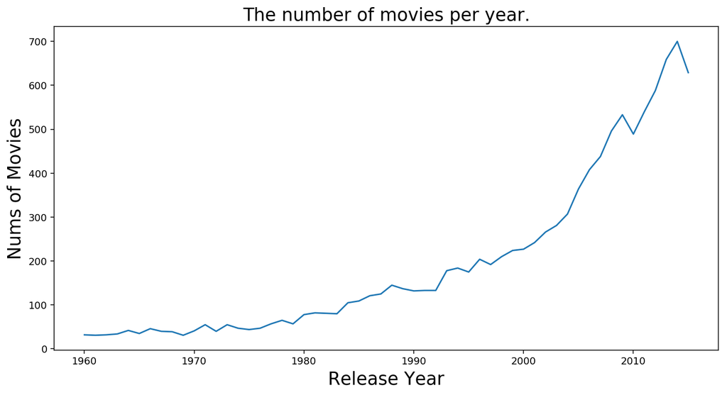

```python
x=df.pivot_table(index=('release_year'), aggfunc='size')
plt.figure(figsize = (12,6), dpi = 140)
# the X label
plt.xlabel('Release Year', fontsize = 18)
# the Y label
plt.ylabel('Nums of Movies', fontsize = 18)
# The name of the graph
plt.title('The number of movies per year.' , fontsize = 18)
plt.plot(x)
plt.show()
```

### Research Question 2: How is the budget of movies has changed over the year?

Plot of the budget_adj and how it changes over the years

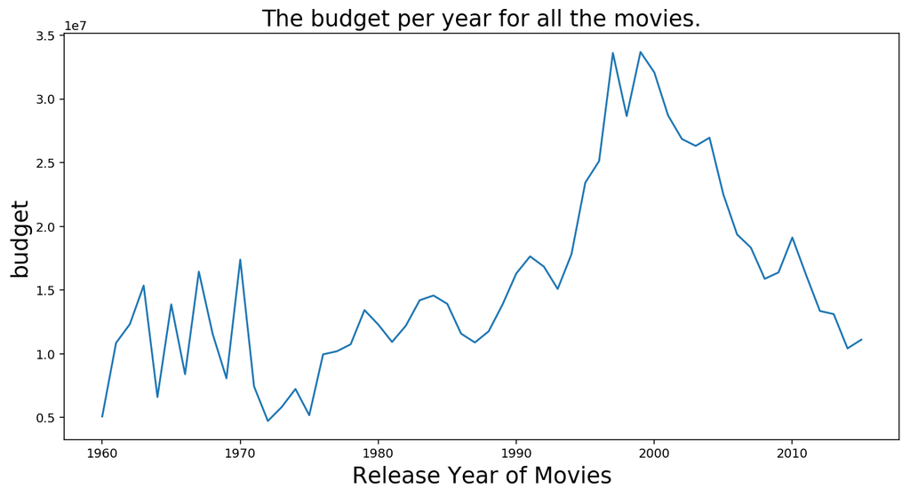

```python
budget_per_year = df.groupby('release_year').mean()['budget_adj']
plt.figure(figsize = (12,6), dpi = 140)
plt.xlabel('Release Year of Movies', fontsize = 18)
plt.ylabel('budget', fontsize = 18)
plt.title('The budget per year for all the movies.' , fontsize = 18)

plt.plot(budget_per_year)

plt.show();
```

### Research Question 3: Which genres are more profitable?

Group the genres column in a new var. Then,Counting the number of movies in every genres.

```python
revenues_genres=dataset.groupby('genres')
revenues_genres['id'].count()
```

```
genres
Action             2384
Adventure          1471
Animation           699
Comedy             3793
Crime              1354
Documentary         520
Drama              4760
Family             1231
Fantasy             916
Foreign             188
History             334
Horror             1637
Music               408
Mystery             810
Romance            1712
Science Fiction    1229
TV Movie            167
Thriller           2907
War                 270
Western             165
Name: id, dtype: int64
```

Grouping the genres column and the mean of revenue_adj in a var

```python
revenues_genres=dataset.groupby('genres')['revenue_adj'].mean()
print(revenues_genres)
```

```
genres
Action             9.175827e+07
Adventure          1.416752e+08
Animation          8.525613e+07
Comedy             4.789700e+07
Crime              5.663641e+07
Documentary        2.258210e+06
Drama              4.041714e+07
Family             8.773671e+07
Fantasy            1.112342e+08
Foreign            1.784286e+06
History            4.794858e+07
Horror             2.408271e+07
Music              4.665592e+07
Mystery            5.088930e+07
Romance            4.820022e+07
Science Fiction    8.697842e+07
TV Movie           3.496353e+05
Thriller           5.528610e+07
War                6.998611e+07
Western            4.610126e+07
Name: revenue_adj, dtype: float64
```

Now we will plot the mean of revenue for the 20 genres in a bar chart.

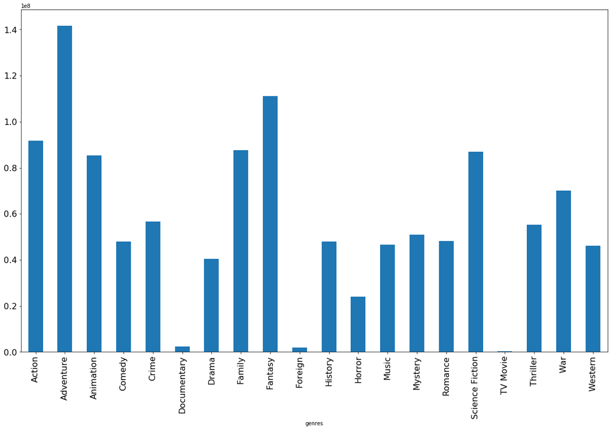

```python
revenues_genres=dataset.groupby('genres')['revenue_adj'].mean().plot(kind='bar', figsize=(20,12), fontsize=16 ,stacked=True)
```

## Conclusions

# Limitaions:

I had trouble trying to prepare the geners column, I felt that I needed a lot of time to spend researching Pandas, other libiriries, and other analysis to understand and figure out how to solve the questions that I have chosen to answer them.

```python
from subprocess import call
call(['python', '-m', 'nbconvert', 'Investigate_a_Dataset.ipynb'])
```

```
0
```